# Overall Objective:

# Know the dataset a little bit

To learn the structure, number of rows, attributes of the dataframe

```python
# Get attribute names
print('Attributs:',data2018.columns)
# Get dataframe shape
print('Dataframe Shape:',data2018.shape)
# Get column data types
for x in data2018.columns:
    print (x,type(data2018[x][0]))
```

```
Attributs: Index(['X', 'Y', 'OBJECTID', 'SERVICECODE', 'SERVICECODEDESCRIPTION',
       'SERVICETYPECODEDESCRIPTION', 'ORGANIZATIONACRONYM', 'SERVICECALLCOUNT',
       'ADDDATE', 'RESOLUTIONDATE', 'SERVICEDUEDATE', 'SERVICEORDERDATE',
       'INSPECTIONFLAG', 'INSPECTIONDATE', 'INSPECTORNAME',
       'SERVICEORDERSTATUS', 'STATUS_CODE', 'SERVICEREQUESTID', 'PRIORITY',
       'STREETADDRESS', 'XCOORD', 'YCOORD', 'LATITUDE', 'LONGITUDE', 'CITY',
       'STATE', 'ZIPCODE', 'MARADDRESSREPOSITORYID', 'WARD', 'DETAILS'],
      dtype='object')
Dataframe Shape: (77776, 30)
X <class 'numpy.float64'>
Y <class 'numpy.float64'>
OBJECTID <class 'numpy.int64'>
SERVICECODE <class 'str'>
SERVICECODEDESCRIPTION <class 'str'>
SERVICETYPECODEDESCRIPTION <class 'str'>
ORGANIZATIONACRONYM <class 'str'>
SERVICECALLCOUNT <class 'numpy.int64'>
ADDDATE <class 'str'>
RESOLUTIONDATE <class 'str'>
SERVICEDUEDATE <class 'str'>
SERVICEORDERDATE <class 'str'>
INSPECTIONFLAG <class 'str'>
INSPECTIONDATE <class 'float'>
INSPECTORNAME <class 'numpy.float64'>
SERVICEORDERSTATUS <class 'str'>
STATUS_CODE <class 'str'>
SERVICEREQUESTID <class 'str'>
PRIORITY <class 'str'>
STREETADDRESS <class 'str'>
XCOORD <class 'numpy.float64'>
YCOORD <class 'numpy.float64'>
LATITUDE <class 'numpy.float64'>
LONGITUDE <class 'numpy.float64'>
CITY <class 'str'>
STATE <class 'str'>
ZIPCODE <class 'numpy.float64'>
MARADDRESSREPOSITORYID <class 'numpy.float64'>
WARD <class 'numpy.float64'>
DETAILS <class 'float'>
```

```python
#Preview the dataframe
data2018.head()
```

|  | X | Y | OBJECTID | SERVICECODE | SERVICECODEDESCRIPTION | SERVICETYPECODEDESCRIPTION | ORGANIZATIONACRONYM | SERVICECALLCOUNT | ADDDATE | RESOLUTIONDATE | ... | XCOORD | YCOORD | LATITUDE | LONGITUDE | CITY | STATE | ZIPCODE | MARADDRESSREPOSITORYID | WARD | DETAILS |
| --- | --- | --- | --- | --- | --- | --- | --- | --- | --- | --- | --- | --- | --- | --- | --- | --- | --- | --- | --- | --- | --- |
| 0 | -76.970417 | 38.864444 | 307864 | DMV01 | DMV - Drivers License/ID Issues | Driver Vehicle Services | DMV | 1 | 2018-01-03T10:14:32.000Z | 2018-01-03T10:18:35.000Z | ... | 402567.660000 | 132957.830000 | 38.864436 | -76.970414 | WASHINGTON | DC | 20020.0 | 301454.0 | 7.0 | NaN |
| 1 | -77.021908 | 38.881287 | 307865 | SIGTRAMA | Traffic Signal Issue | Toa- Trans Sys Mnt | DDOT | 1 | 2018-01-03T09:40:35.000Z | 2018-02-22T08:33:38.000Z | ... | 398099.299996 | 134827.418747 | 38.881280 | -77.021906 | NaN | NaN | 20024.0 | 903906.0 | 6.0 | Traffic signal service request closed to initi... |
| 2 | -77.018693 | 38.930343 | 307866 | S0316 | Recycling Cart Delivery | SWMA- Solid Waste Management Admistration | DPW | 1 | 2018-01-03T10:17:13.000Z | 2018-01-16T15:18:05.000Z | ... | 398379.390000 | 140272.930000 | 38.930336 | -77.018691 | WASHINGTON | DC | 20010.0 | 229343.0 | 1.0 | Closed after ten days no payment received |
| 3 | -77.003177 | 38.903739 | 307867 | SRC02 | Snow/Ice Removal | SNOW | DPW | 1 | 2018-01-03T10:00:39.000Z | 2018-01-08T15:34:03.000Z | ... | 399724.610000 | 137319.480000 | 38.903731 | -77.003175 | WASHINGTON | DC | 20002.0 | 809549.0 | 6.0 | NaN |
| 4 | -76.921593 | 38.901643 | 307868 | S0031 | Bulk Collection | SWMA- Solid Waste Management Admistration | DPW | 1 | 2018-01-03T10:16:53.000Z | 2018-01-12T07:28:01.000Z | ... | 406801.370000 | 137089.690000 | 38.901635 | -76.921591 | WASHINGTON | DC | 20019.0 | 7877.0 | 7.0 | sb - Collected – Close SR |

5 rows × 30 columns

# Preliminary missing values, abnormal values, duplicate rows handling

```python
# Check if there're missing values
data2018.isnull().values.any()
```

```
True
```

```python
# count null values in each column
data2018.isnull().sum()
```

```
X                                 0
Y                                 0
OBJECTID                          0
SERVICECODE                       0
SERVICECODEDESCRIPTION            0
SERVICETYPECODEDESCRIPTION        0
ORGANIZATIONACRONYM               0
SERVICECALLCOUNT                  0
ADDDATE                           0
RESOLUTIONDATE                11902
SERVICEDUEDATE                    3
SERVICEORDERDATE                  0
INSPECTIONFLAG                    0
INSPECTIONDATE                72169
INSPECTORNAME                 77776
SERVICEORDERSTATUS                0
STATUS_CODE                       0
SERVICEREQUESTID                  0
PRIORITY                          0
STREETADDRESS                  5888
XCOORD                            0
YCOORD                            0
LATITUDE                          0
LONGITUDE                         0
CITY                           5886
STATE                          5886
ZIPCODE                           6
MARADDRESSREPOSITORYID          877
WARD                            847
DETAILS                       21239
dtype: int64
```

Since INSPECTIONDATE, INSPECTORNAME have over 70000 null values, these two columns should be deleted. Other null values would be dealt with when we get to specific column.

```python
# Remove INSPECTIONDATE, INSPECTORNAME columns
data2018=data2018.drop('INSPECTIONDATE',axis=1)
data2018=data2018.drop('INSPECTORNAME',axis=1)
```

```python
# Fill in 0 for WARD, MARADDRESSREPOSITORYID columns which are null
data2018.WARD = data2018.WARD.fillna(0)
data2018.MARADDRESSREPOSITORYID =data2018.MARADDRESSREPOSITORYID.fillna(0)
```

```python
# Check for location abnoarmal values
data2018.iloc[:,0:2].describe()
```

|  | X | Y |
| --- | --- | --- |
| count | 77776.000000 | 77776.000000 |
| mean | -77.014328 | 38.911971 |
| std | 0.038531 | 0.030820 |
| min | -77.114209 | 38.813547 |
| 25% | -77.038511 | 38.895054 |
| 50% | -77.018913 | 38.909796 |
| 75% | -76.989322 | 38.932253 |
| max | -76.909760 | 38.995170 |

```python
# Check for duplicate rows
len(data2018.OBJECTID.unique()) ==len(data2018)
```

```
True
```

The location data seem to be in reasonable range, and there's no duplicate rows.

# Clean SERVICECODE, SERVICECODEDESCRIPTION, SERVICECODETYPEDESCRIPTION Columns

To get a dictionary of servicecode with corresbonding description and type. Then remove redundant information from dataframe.

```python
# construct dictionary as dictionary of servicecode and servicecodedescription, servicecodetypedescription
grouped_servicecode_2018=data2018.groupby('SERVICECODE')

dict_servicecode=dict()
for name,group in grouped_servicecode_2018:
    dict_servicecode[name]=group['SERVICECODEDESCRIPTION'].unique(),group['SERVICETYPECODEDESCRIPTION'].unique()

dict_servicecode
```

```
{'11': (array(['Dead Animal Collection'], dtype=object),
  array(['SWMA- Solid Waste Management Admistration'], dtype=object)),
 'BICYCLE': (array(['Abandoned Bicycle'], dtype=object),
  array(['SWMA- Solid Waste Management Admistration'], dtype=object)),
 'C62313': (array(['Christmas Tree Removal-Seasonal'], dtype=object),
  array(['SWMA- Solid Waste Management Admistration'], dtype=object)),
 'CONTREMO': (array(['Container Removal'], dtype=object),
  array(['SWMA- Solid Waste Management Admistration'], dtype=object)),
 'DCGOVTINFO': (array(['DC Government Information'], dtype=object),
  array(['311- Call Center'], dtype=object)),
 'DDENIDTI': (array(['DOEE - Engine Idling Tips'], dtype=object),
  array(['Department of Energy and Environment'], dtype=object)),
 'DDOCONRU': (array(['DOEE - Construction – Erosion Runoff'], dtype=object),
  array(['Department of Energy and Environment'], dtype=object)),
 'DHS06': (array(['DDS - Serious Medication Error'], dtype=object),
  array(['Department of Disability Services'], dtype=object)),
 'DMETTASI': (array(['DMV - eTIMS Ticket Alert Services Issues'], dtype=object),
  array(['Adjudication Services'], dtype=object)),
 'DMINSTIS': (array(['DMV - Vehicle Inspection Issues'], dtype=object),
  array(['Driver Vehicle Services'], dtype=object)),
 'DMPRCEMA': (array(['DMV - Processing Center Manager'], dtype=object),
  array(['Driver Vehicle Services'], dtype=object)),
 'DMV01': (array(['DMV - Drivers License/ID Issues'], dtype=object),
  array(['Driver Vehicle Services'], dtype=object)),
 'DMV08': (array(['DMV - Drivers License/ID Reinstatement'], dtype=object),
  array(['Driver Vehicle Services'], dtype=object)),
 'DMV12': (array(['DMV - Driver Record Issues'], dtype=object),
  array(['Driver Vehicle Services'], dtype=object)),
 'DMV19': (array(['DMV - Vehicle Registration Issues'], dtype=object),
  array(['Driver Vehicle Services'], dtype=object)),
 'DMV31': (array(['DMV - Vehicle Title Issues'], dtype=object),
  array(['Driver Vehicle Services'], dtype=object)),
 'DMV37': (array(['DMV - Vehicle Insurance Lapse'], dtype=object),
  array(['Driver Vehicle Services'], dtype=object)),
 'DMV40': (array(['DMV - Appeal'], dtype=object),
  array(['Adjudication Services'], dtype=object)),
 'DMV43': (array(['DMV - Hearings'], dtype=object),
  array(['Adjudication Services'], dtype=object)),
 'DMV48': (array(['DMV - Ticket Payment Dispute'], dtype=object),
  array(['Adjudication Services'], dtype=object)),
```

[output cut: 144 more lines]

```
  array(['SWMA- Solid Waste Management Admistration'], dtype=object)),
 'SPSTDAMA': (array(['Traffic Safety Investigation'], dtype=object),
  array(['Department of Transportation'], dtype=object)),
 'SRC01': (array(['Snow/Ice Removal (Roadways AND Bridge walkways ONLY)'], dtype=object),
  array(['SNOW'], dtype=object)),
 'SRC02': (array(['Snow/Ice Removal'], dtype=object),
  array(['SNOW'], dtype=object)),
 'TICKOM': (array(['Ticket Ombudsman'], dtype=object),
  array(['Adjudication Services'], dtype=object)),
 'TRACO001': (array(['Trash Cart Repair'], dtype=object),
  array(['SWMA- Solid Waste Management Admistration'], dtype=object)),
 'TRUREPOR': (array(['TRU Report'], dtype=object),
  array(['Tru-311'], dtype=object)),
 'WNTRHYPO': (array(['Homeless Services - Winter/Hypothermia Season'], dtype=object),
  array(['DC Interagency Council on Homelessness'], dtype=object))}
```

```python
# remove SERVICECODEDESCRIPTION,SERVICETYPECODEDESCRIPTION columns in data2018
#data2018=data2018.drop('SERVICECODEDESCRIPTION',axis=1)
#data2018=data2018.drop('SERVICETYPECODEDESCRIPTION',axis=1)
#data2018.head()
```

# Clean CITY, STATE and ZIPCODE data

To get accurate geological categories; Also to deal with null values.Also convert zipcode datatype to int from float.

```python
#check information of CITY and STATE
print('State info:',data2018.STATE.unique())
print('City info:',data2018.CITY.unique())

# check null information of CITY AND STATE
print('State info where city is null',data2018.STATE[data2018.CITY.isnull()== True].unique())

# check null information of zipcode
print('ObjectID whose Zipcode is null:',data2018.OBJECTID[data2018.ZIPCODE.isnull()== True])
```

```
State info: ['DC' nan]
City info: ['WASHINGTON' nan]
State info where city is null [nan]
ObjectID whose Zipcode is null: 24163    334388
32901    348390
34615    350136
39640    357097
40197    357654
46409    365002
Name: OBJECTID, dtype: int64
```

All requests are from Washington DC or have null values. STATE status of rows which CITY status is null is all null. And only 6 rows have null value in ZIPCODE column. So we decided to drop CITY and STATE columns, and delete rows whose ZIPCODE is null.

```python
# Drop CITY and STATE columns
data2018=data2018.drop('CITY',axis=1)
data2018=data2018.drop('STATE',axis=1)
# Delete rows with no zipcode
data2018=data2018[data2018['ZIPCODE'].isnull()!=True]
```

```python
# Convert ZIPCODE datatype from float to int.
data2018.ZIPCODE=data2018.ZIPCODE.astype(int)
```

```python
data2018[data2018.ZIPCODE==-1555]
```

|  | X | Y | OBJECTID | SERVICECODE | SERVICECODEDESCRIPTION | SERVICETYPECODEDESCRIPTION | ORGANIZATIONACRONYM | SERVICECALLCOUNT | ADDDATE | RESOLUTIONDATE | ... | PRIORITY | STREETADDRESS | XCOORD | YCOORD | LATITUDE | LONGITUDE | ZIPCODE | MARADDRESSREPOSITORYID | WARD | DETAILS |
| --- | --- | --- | --- | --- | --- | --- | --- | --- | --- | --- | --- | --- | --- | --- | --- | --- | --- | --- | --- | --- | --- |
| 45735 | -77.025043 | 38.884481 | 364328 | DMV66 | DMV - Copy of Ticket | Adjudication Services | DMV | 1 | 2018-02-27T08:13:08.000Z | 2018-03-05T15:04:08.000Z | ... | STANDARD | 8401 MOUNTAIN | 397827.44 | 135181.95 | 38.884473 | -77.02504 | -1555 | 291726.0 | 6.0 | NaN |

1 rows × 26 columns

```python
data2018=data2018.drop(45735)
```

```python
data2018.head()
```

|  | X | Y | OBJECTID | SERVICECODE | SERVICECODEDESCRIPTION | SERVICETYPECODEDESCRIPTION | ORGANIZATIONACRONYM | SERVICECALLCOUNT | ADDDATE | RESOLUTIONDATE | ... | PRIORITY | STREETADDRESS | XCOORD | YCOORD | LATITUDE | LONGITUDE | ZIPCODE | MARADDRESSREPOSITORYID | WARD | DETAILS |
| --- | --- | --- | --- | --- | --- | --- | --- | --- | --- | --- | --- | --- | --- | --- | --- | --- | --- | --- | --- | --- | --- |
| 0 | -76.970417 | 38.864444 | 307864 | DMV01 | DMV - Drivers License/ID Issues | Driver Vehicle Services | DMV | 1 | 2018-01-03T10:14:32.000Z | 2018-01-03T10:18:35.000Z | ... | STANDARD | 2546 NAYLOR ROAD SE | 402567.660000 | 132957.830000 | 38.864436 | -76.970414 | 20020 | 301454.0 | 7.0 | NaN |
| 1 | -77.021908 | 38.881287 | 307865 | SIGTRAMA | Traffic Signal Issue | Toa- Trans Sys Mnt | DDOT | 1 | 2018-01-03T09:40:35.000Z | 2018-02-22T08:33:38.000Z | ... | STANDARD | NaN | 398099.299996 | 134827.418747 | 38.881280 | -77.021906 | 20024 | 903906.0 | 6.0 | Traffic signal service request closed to initi... |
| 2 | -77.018693 | 38.930343 | 307866 | S0316 | Recycling Cart Delivery | SWMA- Solid Waste Management Admistration | DPW | 1 | 2018-01-03T10:17:13.000Z | 2018-01-16T15:18:05.000Z | ... | STANDARD | 426 KENYON STREET NW | 398379.390000 | 140272.930000 | 38.930336 | -77.018691 | 20010 | 229343.0 | 1.0 | Closed after ten days no payment received |
| 3 | -77.003177 | 38.903739 | 307867 | SRC02 | Snow/Ice Removal | SNOW | DPW | 1 | 2018-01-03T10:00:39.000Z | 2018-01-08T15:34:03.000Z | ... | STANDARD | 200 - 219 BLOCK OF L STREET NE | 399724.610000 | 137319.480000 | 38.903731 | -77.003175 | 20002 | 809549.0 | 6.0 | NaN |
| 4 | -76.921593 | 38.901643 | 307868 | S0031 | Bulk Collection | SWMA- Solid Waste Management Admistration | DPW | 1 | 2018-01-03T10:16:53.000Z | 2018-01-12T07:28:01.000Z | ... | STANDARD | 5528 HUNT PLACE NE | 406801.370000 | 137089.690000 | 38.901635 | -76.921591 | 20019 | 7877.0 | 7.0 | sb - Collected – Close SR |

5 rows × 26 columns

# Clean exact location information

We decided to use LATITUDE and LONGITUDE as excat location coordinates and remove the relative location coordinates columns XCOORD, YCOORD, X, Y, street address

```python
data2018=data2018.drop('XCOORD',axis=1)
data2018=data2018.drop('YCOORD',axis=1)
data2018=data2018.drop('X',axis=1)
data2018=data2018.drop('Y',axis=1)
data2018=data2018.drop('STREETADDRESS',axis=1)
```

```python
data2018.head()
```

|  | OBJECTID | SERVICECODE | SERVICECODEDESCRIPTION | SERVICETYPECODEDESCRIPTION | ORGANIZATIONACRONYM | SERVICECALLCOUNT | ADDDATE | RESOLUTIONDATE | SERVICEDUEDATE | SERVICEORDERDATE | ... | SERVICEORDERSTATUS | STATUS_CODE | SERVICEREQUESTID | PRIORITY | LATITUDE | LONGITUDE | ZIPCODE | MARADDRESSREPOSITORYID | WARD | DETAILS |
| --- | --- | --- | --- | --- | --- | --- | --- | --- | --- | --- | --- | --- | --- | --- | --- | --- | --- | --- | --- | --- | --- |
| 0 | 307864 | DMV01 | DMV - Drivers License/ID Issues | Driver Vehicle Services | DMV | 1 | 2018-01-03T10:14:32.000Z | 2018-01-03T10:18:35.000Z | 2018-01-04T10:14:00.000Z | 2018-01-03T10:14:32.000Z | ... | CLOSED | CLOSED | 18-00003552 | STANDARD | 38.864436 | -76.970414 | 20020 | 301454.0 | 7.0 | NaN |
| 1 | 307865 | SIGTRAMA | Traffic Signal Issue | Toa- Trans Sys Mnt | DDOT | 1 | 2018-01-03T09:40:35.000Z | 2018-02-22T08:33:38.000Z | 2018-01-05T09:40:00.000Z | 2018-01-03T09:40:35.000Z | ... | CLOSED | CLOSED | 18-00003388 | STANDARD | 38.881280 | -77.021906 | 20024 | 903906.0 | 6.0 | Traffic signal service request closed to initi... |
| 2 | 307866 | S0316 | Recycling Cart Delivery | SWMA- Solid Waste Management Admistration | DPW | 1 | 2018-01-03T10:17:13.000Z | 2018-01-16T15:18:05.000Z | 2018-01-31T10:17:00.000Z | 2018-01-03T10:17:13.000Z | ... | CLOSED | CLOSED | 18-00003562 | STANDARD | 38.930336 | -77.018691 | 20010 | 229343.0 | 1.0 | Closed after ten days no payment received |
| 3 | 307867 | SRC02 | Snow/Ice Removal | SNOW | DPW | 1 | 2018-01-03T10:00:39.000Z | 2018-01-08T15:34:03.000Z | 2018-01-04T10:00:39.000Z | 2018-01-03T10:00:39.000Z | ... | CLOSED | CLOSED | 18-00003497 | STANDARD | 38.903731 | -77.003175 | 20002 | 809549.0 | 6.0 | NaN |
| 4 | 307868 | S0031 | Bulk Collection | SWMA- Solid Waste Management Admistration | DPW | 1 | 2018-01-03T10:16:53.000Z | 2018-01-12T07:28:01.000Z | 2018-01-23T10:16:00.000Z | 2018-01-03T10:16:53.000Z | ... | CLOSED | CLOSED | 18-00003559 | STANDARD | 38.901635 | -76.921591 | 20019 | 7877.0 | 7.0 | sb - Collected – Close SR |

5 rows × 21 columns

# Clean MARADDRESSREPOSITORYID,WARD Columns

We've already fill null values with 0. Now we could convert datatype to int from float.

```python
# Convert MARADDRESSREPOSITORYID,WARD Columns datatype to int
data2018.MARADDRESSREPOSITORYID=data2018.MARADDRESSREPOSITORYID.astype(int)
data2018.WARD=data2018.WARD.astype(int)
```

```python
# Check for abnormal values
data2018.WARD.unique()
```

```
array([7, 6, 1, 2, 3, 5, 8, 4, 0], dtype=int64)
```

# Clean datetime columns

```python
# Remove duplicate column
data2018=data2018.drop('SERVICEORDERDATE',axis=1)
```

```python
# Transform 4 columns containing time series data to clean form
data2018['ADDDATE'] = pd.to_datetime(data2018['ADDDATE'], format='%Y-%m-%dT%H:%M:%S')
data2018['RESOLUTIONDATE'] = pd.to_datetime(data2018['RESOLUTIONDATE'], format='%Y-%m-%dT%H:%M:%S')
data2018['SERVICEDUEDATE'] = pd.to_datetime(data2018['SERVICEDUEDATE'], format='%Y-%m-%dT%H:%M:%S')
```

```python
data2018.head()
```

|  | OBJECTID | SERVICECODE | SERVICECODEDESCRIPTION | SERVICETYPECODEDESCRIPTION | ORGANIZATIONACRONYM | SERVICECALLCOUNT | ADDDATE | RESOLUTIONDATE | SERVICEDUEDATE | INSPECTIONFLAG | SERVICEORDERSTATUS | STATUS_CODE | SERVICEREQUESTID | PRIORITY | LATITUDE | LONGITUDE | ZIPCODE | MARADDRESSREPOSITORYID | WARD | DETAILS |
| --- | --- | --- | --- | --- | --- | --- | --- | --- | --- | --- | --- | --- | --- | --- | --- | --- | --- | --- | --- | --- |
| 0 | 307864 | DMV01 | DMV - Drivers License/ID Issues | Driver Vehicle Services | DMV | 1 | 2018-01-03 10:14:32 | 2018-01-03 10:18:35 | 2018-01-04 10:14:00 | N | CLOSED | CLOSED | 18-00003552 | STANDARD | 38.864436 | -76.970414 | 20020 | 301454 | 7 | NaN |
| 1 | 307865 | SIGTRAMA | Traffic Signal Issue | Toa- Trans Sys Mnt | DDOT | 1 | 2018-01-03 09:40:35 | 2018-02-22 08:33:38 | 2018-01-05 09:40:00 | N | CLOSED | CLOSED | 18-00003388 | STANDARD | 38.881280 | -77.021906 | 20024 | 903906 | 6 | Traffic signal service request closed to initi... |
| 2 | 307866 | S0316 | Recycling Cart Delivery | SWMA- Solid Waste Management Admistration | DPW | 1 | 2018-01-03 10:17:13 | 2018-01-16 15:18:05 | 2018-01-31 10:17:00 | N | CLOSED | CLOSED | 18-00003562 | STANDARD | 38.930336 | -77.018691 | 20010 | 229343 | 1 | Closed after ten days no payment received |
| 3 | 307867 | SRC02 | Snow/Ice Removal | SNOW | DPW | 1 | 2018-01-03 10:00:39 | 2018-01-08 15:34:03 | 2018-01-04 10:00:39 | Y | CLOSED | CLOSED | 18-00003497 | STANDARD | 38.903731 | -77.003175 | 20002 | 809549 | 6 | NaN |
| 4 | 307868 | S0031 | Bulk Collection | SWMA- Solid Waste Management Admistration | DPW | 1 | 2018-01-03 10:16:53 | 2018-01-12 07:28:01 | 2018-01-23 10:16:00 | N | CLOSED | CLOSED | 18-00003559 | STANDARD | 38.901635 | -76.921591 | 20019 | 7877 | 7 | sb - Collected – Close SR |

# Remove other irrelevant columns and rename remaining columns

```python
# Remove other irrelevant columns
data2018=data2018.drop('SERVICECALLCOUNT',axis=1)
data2018=data2018.drop('INSPECTIONFLAG',axis=1)
data2018=data2018.drop('STATUS_CODE',axis=1)
```

```python
# Rename remaining columns
data2018.columns = ['object_id','service_code','service_description','service_category','organization_acronym','add_date','resolution_date','servicedue_date','service_status','service_request_id','priority','latitude','longitude','zipcode','address_repository_id','ward','details']
```

```python
#reset index
data2018.set_index('add_date', inplace=True)
```

```python
data2018['complete_time']=data2018['resolution_date']-data2018.index
```

```python
df=data2018
df.head(5)
```

| add_date | object_id | service_code | service_description | service_category | organization_acronym | resolution_date | servicedue_date | service_status | service_request_id | priority | latitude | longitude | zipcode | address_repository_id | ward | details | complete_time |
| --- | --- | --- | --- | --- | --- | --- | --- | --- | --- | --- | --- | --- | --- | --- | --- | --- | --- |
| 2018-01-03 10:14:32 | 307864 | DMV01 | DMV - Drivers License/ID Issues | Driver Vehicle Services | DMV | 2018-01-03 10:18:35 | 2018-01-04 10:14:00 | CLOSED | 18-00003552 | STANDARD | 38.864436 | -76.970414 | 20020 | 301454 | 7 | NaN | 0 days 00:04:03 |
| 2018-01-03 09:40:35 | 307865 | SIGTRAMA | Traffic Signal Issue | Toa- Trans Sys Mnt | DDOT | 2018-02-22 08:33:38 | 2018-01-05 09:40:00 | CLOSED | 18-00003388 | STANDARD | 38.881280 | -77.021906 | 20024 | 903906 | 6 | Traffic signal service request closed to initi... | 49 days 22:53:03 |
| 2018-01-03 10:17:13 | 307866 | S0316 | Recycling Cart Delivery | SWMA- Solid Waste Management Admistration | DPW | 2018-01-16 15:18:05 | 2018-01-31 10:17:00 | CLOSED | 18-00003562 | STANDARD | 38.930336 | -77.018691 | 20010 | 229343 | 1 | Closed after ten days no payment received | 13 days 05:00:52 |
| 2018-01-03 10:00:39 | 307867 | SRC02 | Snow/Ice Removal | SNOW | DPW | 2018-01-08 15:34:03 | 2018-01-04 10:00:39 | CLOSED | 18-00003497 | STANDARD | 38.903731 | -77.003175 | 20002 | 809549 | 6 | NaN | 5 days 05:33:24 |
| 2018-01-03 10:16:53 | 307868 | S0031 | Bulk Collection | SWMA- Solid Waste Management Admistration | DPW | 2018-01-12 07:28:01 | 2018-01-23 10:16:00 | CLOSED | 18-00003559 | STANDARD | 38.901635 | -76.921591 | 20019 | 7877 | 7 | sb - Collected – Close SR | 8 days 21:11:08 |

# Data is now cleaned and prepared well for analysis!!!

# I. About Request Complete Time

```python
#transform compelte_time from delta time to days
df['complete_time']=[x.days for x in df['complete_time']]
```

## i. Plot average request complete time of each day

```
Text(0.5,0,'day of 2018')
```

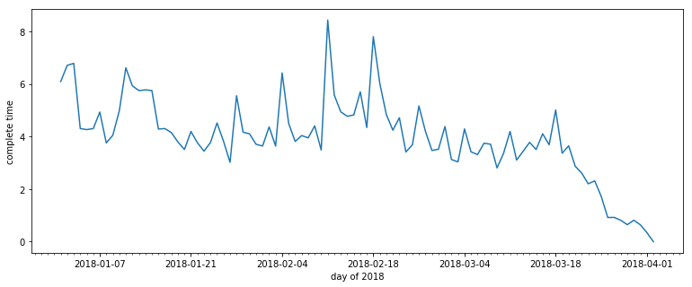

```python
# Downsample count of request to daily measurements
from matplotlib import dates
days = dates.DayLocator()

fig = plt.figure(figsize=(13,5))
ax = fig.add_subplot(111)
#ax.xaxis.set_major_locator(days)
#ax.xaxis.set_major_formatter(dfmt)
ax.xaxis.set_minor_locator(days)

ax.plot(df['complete_time'].resample('D').mean())
ax.set_ylabel('complete time')
ax.set_xlabel('day of 2018')

#plt.legend(('# of service'))
#plt.xticks(arange(130, step=1))  # 201 since you want 200 displayed in the grap
```

We discovered several interesting things:

- After mid March of 2018, there's a significant drop of average request completion time
- There's a peak in early Feburary

So we zoom in from 2 perspectives:

- What happend on the peak day
- What caused the significant drop of average request completion time

## ii. On request complete_time peak day

```python
# Find out what happened on the day when complete time peaked
y=df['complete_time'].resample('D').mean()
ymax = max(y)
xmax = y[y==ymax]
print(xmax,ymax)
```

```
add_date
2018-02-11    8.438596
Freq: D, Name: complete_time, dtype: float64 8.43859649123
```

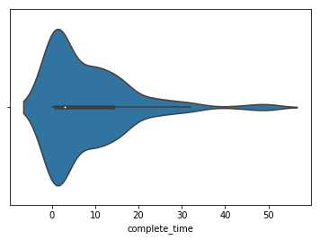

```python
# Distribution of request complete time
sns.violinplot(df['2018-02-11'].complete_time)
```

```python
df[df.complete_time>30]['2018-02-11']
```

| add_date | object_id | service_code | service_description | service_category | organization_acronym | resolution_date | servicedue_date | service_status | service_request_id | priority | latitude | longitude | zipcode | address_repository_id | ward | details | complete_time |
| --- | --- | --- | --- | --- | --- | --- | --- | --- | --- | --- | --- | --- | --- | --- | --- | --- | --- |
| 2018-02-11 12:07:15 | 346797 | DDENIDTI | DOEE - Engine Idling Tips | Department of Energy and Environment | DOEE | 2018-04-02 12:11:15 | 2018-02-26 18:00:00 | CLOSED | 18-00072990 | STANDARD | 38.887445 | -76.983413 | 20003 | 300665 | 6 | NaN | 50.0 |
| 2018-02-11 12:11:18 | 346799 | HMDCP | How Is My Driving - Complaint | HOMYDRPR- How Is My Driving Program | ORM | 2018-03-19 10:08:20 | 2018-03-26 17:00:00 | CLOSED | 18-00072992 | STANDARD | 38.886765 | -76.982006 | 20003 | 60549 | 6 | NaN | 35.0 |
| 2018-02-11 13:28:14 | 346810 | S0459 | Tree Removal | Urban Forrestry | DDOT | 2018-03-29 08:43:07 | 2018-10-23 17:00:00 | CLOSED | 18-00073032 | STANDARD | 38.882610 | -76.962579 | 20019 | 40557 | 7 | The remainder of the tree is now scheduled to ... | 45.0 |
| 2018-02-11 14:10:26 | 346816 | S0301 | Pothole | Toa-Street & Bridge Maintenance | DDOT | 2018-04-02 18:08:26 | 2018-02-14 18:00:00 | CLOSED | 18-00073059 | STANDARD | 38.889435 | -77.035232 | 20004 | 313458 | 2 | Close%3a Inspection Completed. Work already d... | 50.0 |
| 2018-02-11 14:11:39 | 346821 | S0301 | Pothole | Toa-Street & Bridge Maintenance | DDOT | 2018-04-02 10:28:28 | 2018-02-14 18:00:00 | CLOSED | 18-00073061 | STANDARD | 38.914785 | -77.056235 | 20008 | 811430 | 2 | NaN | 49.0 |
| 2018-02-11 21:27:44 | 346875 | S0301 | Pothole | Toa-Street & Bridge Maintenance | DDOT | 2018-04-02 10:28:26 | 2018-02-14 18:00:00 | CLOSED | 18-00073273 | STANDARD | 38.914785 | -77.056235 | 20008 | 811430 | 2 | NaN | 49.0 |
| 2018-02-11 21:36:49 | 346876 | S0301 | Pothole | Toa-Street & Bridge Maintenance | DDOT | 2018-03-16 13:23:23 | 2018-02-14 18:00:00 | CLOSED | 18-00073277 | STANDARD | 38.917977 | -76.970600 | 20002 | 287175 | 5 | Close%3a Inspection Completed. Work already d... | 32.0 |
| 2018-02-11 01:09:52 | 346939 | GRAFF | Graffiti Removal | SWMA- Solid Waste Management Admistration | DPW | 2018-03-26 13:53:33 | 2018-02-26 18:00:00 | CLOSED | 18-00072899 | STANDARD | 38.900796 | -76.941725 | 20019 | 25250 | 7 | Location completed by C.Hamitlon and K.Tapscott. | 43.0 |
| 2018-02-11 04:11:49 | 346945 | S0301 | Pothole | Toa-Street & Bridge Maintenance | DDOT | 2018-03-15 13:23:33 | 2018-02-14 18:00:00 | CLOSED | 18-00072918 | STANDARD | 38.940601 | -77.035409 | 20011 | 259127 | 4 | Close%3a Inspection Completed. Work already d... | 32.0 |
| 2018-02-11 17:59:45 | 347592 | S0301 | Pothole | Toa-Street & Bridge Maintenance | DDOT | 2018-03-15 18:43:18 | 2018-02-14 18:00:00 | CLOSED | 18-00073194 | STANDARD | 38.955305 | -77.068296 | 20008 | 221332 | 3 | The pothole(s) at this location have been repa... | 32.0 |
| 2018-02-11 20:48:30 | 347634 | OUTODOR | DOEE - Nuisance Odor Complaints | Department of Energy and Environment | DOEE | 2018-04-02 12:36:48 | 2018-02-26 18:00:00 | CLOSED | 18-00073264 | STANDARD | 38.948636 | -77.020557 | 20011 | 247241 | 4 | NaN | 49.0 |
| 2018-02-11 23:32:16 | 348166 | S04TP | Tree Planting | Urban Forrestry | DDOT | 2018-03-16 13:48:13 | 2020-01-27 18:00:00 | CLOSED | 18-00073309 | STANDARD | 38.917535 | -77.023088 | 20001 | 284162 | 1 | NaN | 32.0 |

```python
df[df.complete_time>40]['service_description'].value_counts().head(10)
```

```
Graffiti Removal                          107
Pothole                                    29
Streetlight Repair Investigation           26
How Is My Driving - Complaint              22
Roadway Signs                              21
Tree Pruning                               14
Tree Planting                              12
Abandoned Vehicle - On Public Property     10
Parking Meter Repair                        8
FEMS - Community Events                     8
Name: service_description, dtype: int64
```

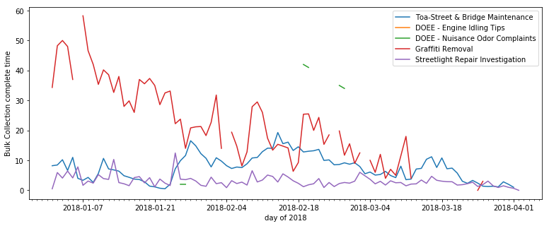

```python
# Downsample count of request to daily measurements
from matplotlib import dates
days = dates.DayLocator()

fig = plt.figure(figsize=(13,5))
ax = fig.add_subplot(111)
#ax.xaxis.set_major_locator(days)
#ax.xaxis.set_major_formatter(dfmt)
ax.xaxis.set_minor_locator(days)

ax.plot(df[df.service_category=='Toa-Street & Bridge Maintenance']['complete_time'].resample('D').mean())
ax.plot(df[df.service_description=='DOEE - Engine Idling Tips']['complete_time'].resample('D').mean())
ax.plot(df[df.service_description=='DOEE - Nuisance Odor Complaints']['complete_time'].resample('D').mean())
ax.plot(df[df.service_description=='Graffiti Removal']['complete_time'].resample('D').mean())
ax.plot(df[df.service_description=='Streetlight Repair Investigation']['complete_time'].resample('D').mean())
ax.set_ylabel('Bulk Collection complete time')
ax.set_xlabel('day of 2018')
plt.legend(('Toa-Street & Bridge Maintenance', 'DOEE - Engine Idling Tips','DOEE - Nuisance Odor Complaints','Graffiti Removal','Streetlight Repair Investigation'))

#plt.xticks(arange(130, step=1))  # 201 since you want 200 displayed in the grap
```

## iii. Break-down by service categories with most requests

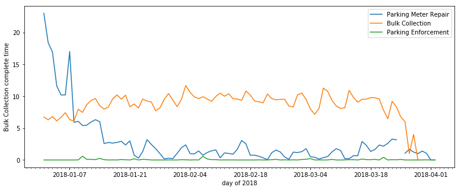

```python
# Downsample count of request to daily measurements
from matplotlib import dates
days = dates.DayLocator()

fig = plt.figure(figsize=(13,5))
ax = fig.add_subplot(111)
#ax.xaxis.set_major_locator(days)
#ax.xaxis.set_major_formatter(dfmt)
ax.xaxis.set_minor_locator(days)

ax.plot(df[df.service_description=='Parking Meter Repair']['complete_time'].resample('D').mean())
ax.plot(df[df.service_description=='Bulk Collection']['complete_time'].resample('D').mean())
ax.plot(df[df.service_description=='Parking Enforcement']['complete_time'].resample('D').mean())
ax.set_ylabel('Bulk Collection complete time')
ax.set_xlabel('day of 2018')
plt.legend(('Parking Meter Repair', 'Bulk Collection','Parking Enforcement'))

#plt.legend(('# of service'))
#plt.xticks(arange(130, step=1))  # 201 since you want 200 displayed in the grap
```

From the requests which took longest to complete on 2018-02-11, we dicovered that they're mostly from Toa-Street & Bridge Maintenance and Department of Energy and Environment. After plotting these three categories throughout the year, we further identified that Engine idling tips seldom occurs, and nuisance oder complaints occured several times and Street & Bridge Maintenance requests are filed basically everyday. After plotting requests with more than complete time of 40 days, we dicovered the following trend:

- Graffitti took the longest time to complete a request. Over 2018, the efficiency improved significantly. There might have been a graffiti removal program which ended at late March.
- Street and Bridge maintainence mostly accounts for the peak of complete time on Febuary 11st for the request number. And the complete time of this category peaked in February and was flunctuating around the same level. And there's a slight drop from mid March
- Among the most filed requests category, bulk collection took the logest time. And its complete time dropped significantly after mid March.
- Parking meter requests dropped significantly from early January and remaind at a lpw level.

So we made the following proposal:

- Focus more on street and bridge maintenance efficiency as next step to improve request completion efficiency.
- Keep Parking meter repair system at the same service level.

# II. About requests in different wards

## i. Distribution of requests among categories

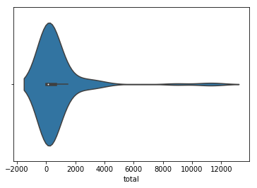

```python
# pivot table of service categories and wards on counts
table_ward_service_cat=data2018.pivot_table(index='service_description', columns='ward', values='object_id', aggfunc='count', fill_value=0)
table_ward_service_cat['total']=table_ward_service_cat.sum(axis=1)

# Draw violin plot on service description to see the distribution
sns.violinplot(table_ward_service_cat['total'])
```

```python
table_ward_service_cat.total.describe()
```

```
count      100.000000
mean       777.690000
std       1916.630064
min          1.000000
25%         22.750000
50%        115.000000
75%        618.000000
max      11683.000000
Name: total, dtype: float64
```

From the distribution, we discovered 6 categories that have way more requests than the other categories. First we analyze their distribution among wards.

## ii. top categories among wards

```python
table_ward_service_cat_top=table_ward_service_cat[table_ward_service_cat.total>3000]
# drop total column
table_ward_service_cat_top=table_ward_service_cat_top.drop('total',axis=1)
```

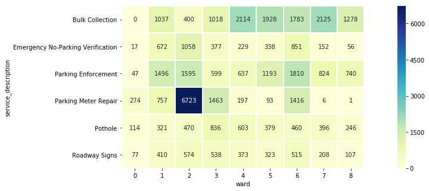

```python
# Plot request frequncies in categories and wards
plt.figure(figsize=(20,5))
sns.heatmap(table_ward_service_cat_top, cmap='YlGnBu', annot=True, fmt='d', square=True, linewidths=1);
```

As in the heatmap, we discovered the following patterns:

- More than half of Parking Meter Repair requests are in ward 2, which is the downtown area
- There're equally large amount of bulk collection requests in ward 4 to 7, which is the north and east periferal of DC
- In ward 6, there're significant amount of parking enforcement,emergency no-parking verification and parking meter repair requests. These're all related with parking issues.
- Aside from bulk collection, most of the requests are related to parking.

We made the following proposals:

- Improve parking system in ward 6.
- Examine meter hardware and softeare systems in ward 2 to reduce parking meter malfunction.

## iii. Where does the reduction of bulk collection requests happend

```python
#convert dataset to day-period
df1=data2018.to_period('D')

table_bulk_com=df1[df1.service_description=='Bulk Collection'].pivot_table(index='add_date', columns='ward', values='complete_time', aggfunc='mean', fill_value=0)
table_bulk_com=table_bulk_cat.loc['20180301':'20180329']

table_bulk_cat=df1[df1.service_description=='Bulk Collection'].pivot_table(index='add_date', columns='ward', values='object_id', aggfunc='count', fill_value=0)
table_bulk_cat=table_bulk_cat.loc['20180301':'20180329']
```

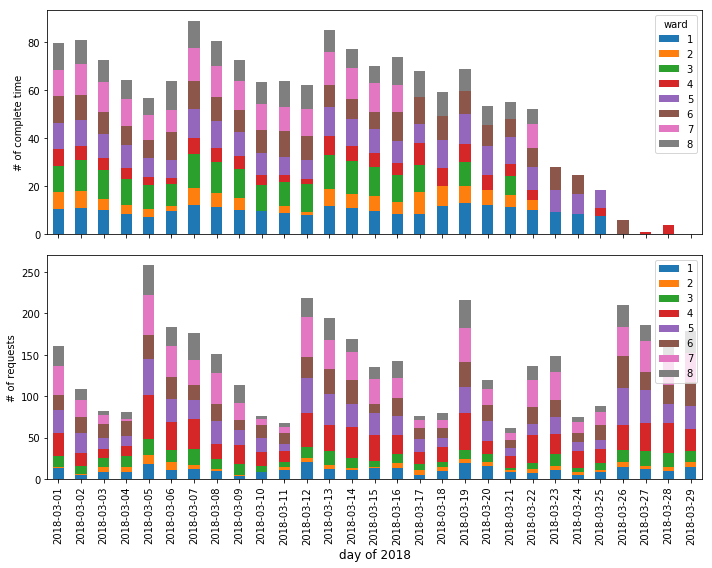

```python
fig, ax = plt.subplots(2, 1, sharex=True, figsize=(10,8))

table_bulk_com.plot(kind='bar', stacked=True,ax=ax[0])
plt.legend(loc='upper right')
plt.ylabel('# of complete time')
plt.xlabel('day of 2018')

table_bulk_cat.plot(kind='bar', stacked=True,ax=ax[1])
plt.legend(loc='upper right')
plt.ylabel('# of requests')
plt.xlabel('day of 2018')

# Adjust figure labels
ax[0].set_ylabel('# of complete time')
ax[1].set_ylabel('# of requests')
ax[1].set_xlabel('day of 2018', fontsize=12);

# Adjust subplot
plt.tight_layout()
```

Observed the huge reduction from 2018 mid March in bulk collection reuqests, we drew a bar chart to find out why and where this happend. And we found out:

- Bulk collection complete time in ward 7,8 and 2 significantly reduced while the number of daily requests remained the same.

So we'd examine the actions of above wards and propose to implement them in other wards.

## iv. Other categories among wards

```python
# table_ward_service_cat=table_ward_service_cat.iloc[3:]
# filter out extremes
table_ward_service_cat=table_ward_service_cat[table_ward_service_cat.total>700]
table_ward_service_cat=table_ward_service_cat[table_ward_service_cat.total<3000]

# drop total column
table_ward_service_cat=table_ward_service_cat.drop('total',axis=1)
# transpose the table
table_ward_service_cat=table_ward_service_cat.transpose()
```

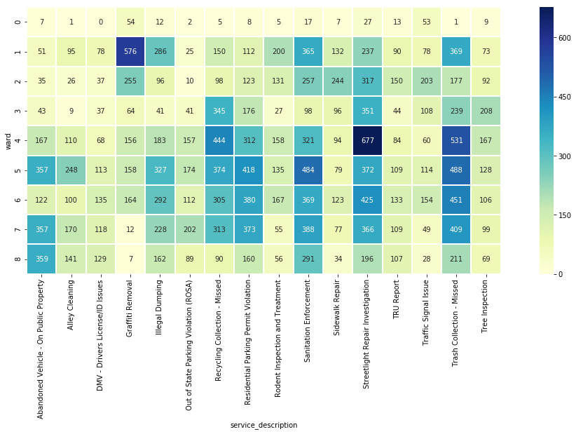

```python
# Plot request frequncies in categories and wards
plt.figure(figsize=(20,7))
sns.heatmap(table_ward_service_cat, cmap='YlGnBu', annot=True, fmt='d', square=True, linewidths=1);
```

Plotted the rest categories, we discovered the following pattern:

- Streetlight Repair Investigation requests occurs the most in ward4.Graffiti removal requests occured the most in ward 1.